# TCGA Breast Cancer: Multi-Omic Biomarker Discovery with stablr

```r
knitr::opts_chunk$set(
  collapse  = TRUE,
  comment   = "#>",
  fig.width  = 6,
  fig.height = 4,
  cache      = FALSE,
  cache.path = "stablr-tcga-cache/"
)
```

## Overview

This vignette translates the **mixOmics N-Integration Chapter 6** case study into the `stablr` idiom. The original mixOmics workflow uses sparse multi-block Discriminant Analysis (sgccaDA) to classify breast cancer subtypes. Here we ask the same scientific question — which mRNA and miRNA features robustly distinguish Basal-like tumours from all other subtypes? — using STABL’s bootstrap stability approach.

**Dataset:** `breast.TCGA` from the `mixOmics` package.

**What you will learn:**

1. How to load and prepare `breast.TCGA` for `stablr`.
2. How to run per-omic STABL as a baseline.
3. How to run the integrated multi-omic pipeline (early + late fusion).
4. How to evaluate validation performance with confusion matrices and BER.
5. How to export results for downstream reporting.

## Prerequisites

```r
if (!requireNamespace("mixOmics", quietly = TRUE)) {
  stop(
    "This vignette requires mixOmics (Bioconductor). ",
    "Install with: BiocManager::install('mixOmics')"
  )
}
library(stablr)
library(mixOmics)
```

## 1. Load and prepare data

`breast.TCGA` is a named list with `$data.train` and `$data.test`, each containing `$mrna`, `$mirna`, `$protein`, and `$subtype`.

```r
data(breast.TCGA)

X_train_mrna  <- breast.TCGA$data.train$mrna
X_train_mirna <- breast.TCGA$data.train$mirna
X_test_mrna   <- breast.TCGA$data.test$mrna
X_test_mirna  <- breast.TCGA$data.test$mirna

cat("Training mRNA:  ", nrow(X_train_mrna),  "x", ncol(X_train_mrna),  "\n")
```

```
#> Training mRNA:   150 x 200
```

```r
cat("Training miRNA: ", nrow(X_train_mirna), "x", ncol(X_train_mirna), "\n")
```

```
#> Training miRNA:  150 x 184
```

```r
cat("Test mRNA:      ", nrow(X_test_mrna),   "x", ncol(X_test_mrna),   "\n")
```

```
#> Test mRNA:       70 x 200
```

```r
cat("Test miRNA:     ", nrow(X_test_mirna),  "x", ncol(X_test_mirna),  "\n")
```

```
#> Test miRNA:      70 x 184
```

### Binary outcome: Basal vs. non-Basal

```r
subtype_train <- breast.TCGA$data.train$subtype
subtype_test  <- breast.TCGA$data.test$subtype

y_train <- as.integer(subtype_train == "Basal")
y_test  <- as.integer(subtype_test  == "Basal")

names(y_train) <- rownames(X_train_mrna)
names(y_test)  <- rownames(X_test_mrna)

cat("Training: ", sum(y_train), "Basal /", sum(y_train == 0), "non-Basal\n")
```

```
#> Training:  45 Basal / 105 non-Basal
```

```r
cat("Test:     ", sum(y_test),  "Basal /", sum(y_test == 0),  "non-Basal\n")
```

```
#> Test:      21 Basal / 49 non-Basal
```

## 2. Per-omic STABL

We assess each omic independently before running integration. `n_bootstraps = 50` is used here for a vignette-friendly runtime; increase to 500-1000 for publication results.

### 2a. mRNA

```r
lambda_mrna <- auto_lambda_grid(
  X_train_mrna, y_train,
  family   = "binomial",
  n_lambda = 20
)
```

```r
fit_mrna <- stabl_fit(
  x               = X_train_mrna,
  y               = y_train,
  lambda_grid     = lambda_mrna,
  family          = "binomial",
  n_bootstraps    = 50L,
  artificial_type = "random_permutation",
  random_state    = 42L
)
fit_mrna
```

```
#> <stabl_fit>
#>   Features in:      200
#>   Features selected: 32
#>   Min FDP+:         0.0312
#>   FDP+ threshold:   0.22
#>   Artificial:       random_permutation
```

### 2b. miRNA

```r
lambda_mirna <- auto_lambda_grid(
  X_train_mirna, y_train,
  family   = "binomial",
  n_lambda = 20
)
```

```r
fit_mirna <- stabl_fit(
  x               = X_train_mirna,
  y               = y_train,
  lambda_grid     = lambda_mirna,
  family          = "binomial",
  n_bootstraps    = 50L,
  artificial_type = "random_permutation",
  random_state    = 42L
)
fit_mirna
```

```
#> <stabl_fit>
#>   Features in:      184
#>   Features selected: 10
#>   Min FDP+:         0.1
#>   FDP+ threshold:   0.5
#>   Artificial:       random_permutation
```

### Per-omic selected features

```r
cat("mRNA selected features:\n")
```

```
#> mRNA selected features:
```

```r
print(get_support(fit_mrna))
```

```
#>      RTN2     NDRG2   CCDC113    FAM63A     ACADS      GMDS     HLA-H    SEMA4A
#>     FALSE      TRUE     FALSE     FALSE     FALSE     FALSE     FALSE     FALSE
#>      ETS2     LIMD2      NME3      ZEB1     CDCP1     GIYD2     RTKN2    MANSC1
#>     FALSE     FALSE     FALSE     FALSE     FALSE     FALSE     FALSE     FALSE
#>     TAGLN     IFIT3     ARL4C     HTRA1    KIF13B    CPPED1     SKAP2      ASPM
#>     FALSE     FALSE     FALSE     FALSE     FALSE     FALSE     FALSE     FALSE
#>     KDM4B    TBXAS1      MT1X    MED13L    SNORA8      RGS1      CBX6      WWC2
#>     FALSE     FALSE     FALSE     FALSE      TRUE     FALSE     FALSE     FALSE
#> TNFRSF12A    ZNF552    MAPRE2    SEMA5A    STAT5A      FLI1   COL15A1   C7orf55
#>     FALSE      TRUE     FALSE     FALSE     FALSE     FALSE     FALSE     FALSE
#>     ASF1B      FUT8     LASS4      SQLE      GPC4    AKAP12       AGL   ADAMTS4
#>     FALSE      TRUE     FALSE     FALSE     FALSE     FALSE     FALSE     FALSE
#>     EPHB3    MAP3K1      PRNP     PROM2   SLCO3A1     SNHG1   PRKCDBP      MXI1
#>      TRUE     FALSE     FALSE     FALSE     FALSE     FALSE     FALSE     FALSE
#>     CSF1R     TANC2   SLC19A2      RHOU   C4orf34     LRIG1     DOCK8       BOC
#>     FALSE      TRUE     FALSE     FALSE      TRUE      TRUE     FALSE     FALSE
#>  C11orf52   S100A16     NRARP     TTC23    TBC1D4    DEPDC6     ILDR1      SDC1
#>     FALSE     FALSE     FALSE     FALSE      TRUE     FALSE     FALSE     FALSE
#>      STC2     DTWD2      TCF4     ITPR2      DPYD      NME1     EGLN3     CD302
#>     FALSE      TRUE     FALSE     FALSE     FALSE     FALSE     FALSE     FALSE
#>       AHR   LAPTM4B      OCLN HIST1H2BK    HDAC11   C18orf1  C6orf192     AMPD3
#>     FALSE     FALSE     FALSE     FALSE     FALSE     FALSE     FALSE     FALSE
#>    COL6A1   RAB3IL1   APBB1IP     PSIP1   EIF2AK2     CSRP2  EIF4EBP3       LYN
#>     FALSE     FALSE     FALSE      TRUE     FALSE     FALSE     FALSE      TRUE
#>     WDR76    SAMD9L      ASPH      RBL1   SLC43A3       HN1    TTC39A      MTL5
#>     FALSE     FALSE     FALSE     FALSE      TRUE     FALSE      TRUE     FALSE
#>       NES      APOD      RIN3     ALCAM   C1orf38     PLCD3     BSPRY      NTN4
#>      TRUE     FALSE      TRUE      TRUE     FALSE     FALSE     FALSE     FALSE
#>     IL1R1      EMP3   ZKSCAN1     FMNL2    OGFRL1      IRF5     IGSF3       DBP
#>     FALSE     FALSE     FALSE     FALSE      TRUE     FALSE     FALSE     FALSE
#>      CNN2    CAMK2D    SIGIRR     AKAP9      ICA1      FGD5      DSG2      E2F1
#>     FALSE     FALSE     FALSE     FALSE     FALSE     FALSE     FALSE     FALSE
#>     QSOX1      TOB1     CSF3R   SHROOM3    CCDC80     FRMD6    CXCL12     CCNA2
#>     FALSE     FALSE     FALSE      TRUE     FALSE     FALSE     FALSE     FALSE
#>     TIGD5   ALDH6A1     POSTN      FZD4    NCAPG2      SDC4     SNED1   PLEKHA4
#>      TRUE     FALSE     FALSE     FALSE      TRUE     FALSE     FALSE     FALSE
#>    KCNAB2   SH3KBP1     IGSF9      DNLZ     S1PR3     PTPRE  FLJ23867    PLSCR1
#>     FALSE     FALSE     FALSE     FALSE     FALSE     FALSE      TRUE     FALSE
#>      LMO4    IFITM2    LRRC25       TST      NCF4     NCOA7      IL4R   CCDC64B
#>     FALSE     FALSE     FALSE     FALSE     FALSE     FALSE     FALSE     FALSE
#>     SGPP1     RUNX3    SLC5A6     IFIH1     PREX1     PLAUR     CDK18   SLC43A2
#>     FALSE     FALSE      TRUE     FALSE      TRUE     FALSE      TRUE     FALSE
#>        GK     ICAM2     YPEL2      CBR1     MEX3A     ZNRF3     PTPRM  C1orf162
#>     FALSE     FALSE      TRUE      TRUE      TRUE     FALSE     FALSE     FALSE
#>      GAS6      C1QB     PVRL4      CTSK     MRVI1      LEF1     PLCD4    ZNF37B
#>     FALSE     FALSE     FALSE     FALSE     FALSE     FALSE     FALSE     FALSE
#>     MEGF9     GINS2    FAM13A     CPT1A     SNX10    TRIM45      ELP2     ALOX5
#>      TRUE     FALSE     FALSE      TRUE     FALSE     FALSE     FALSE     FALSE
#>      AMN1    CERCAM    SEMA3C      KRT8  TP53INP2      JAM3    ZNF680      PBX1
#>     FALSE     FALSE      TRUE      TRUE     FALSE     FALSE     FALSE     FALSE
```

```r
cat("\nmiRNA selected features:\n")
```

```
#>
#> miRNA selected features:
```

```r
print(get_support(fit_mirna))
```

```
#>   hsa-let-7a-1   hsa-let-7a-2   hsa-let-7a-3     hsa-let-7b     hsa-let-7c
#>          FALSE          FALSE          FALSE          FALSE          FALSE
#>     hsa-let-7d     hsa-let-7e   hsa-let-7f-1   hsa-let-7f-2     hsa-let-7g
#>          FALSE          FALSE          FALSE          FALSE          FALSE
#>     hsa-let-7i    hsa-mir-100  hsa-mir-101-1  hsa-mir-101-2  hsa-mir-103-1
#>          FALSE          FALSE          FALSE          FALSE          FALSE
#>  hsa-mir-103-2   hsa-mir-106a   hsa-mir-106b    hsa-mir-107    hsa-mir-10a
#>          FALSE           TRUE           TRUE          FALSE          FALSE
#>    hsa-mir-10b   hsa-mir-125a hsa-mir-125b-1    hsa-mir-126    hsa-mir-127
#>          FALSE          FALSE          FALSE          FALSE          FALSE
#>  hsa-mir-128-1  hsa-mir-128-2   hsa-mir-1287   hsa-mir-1301   hsa-mir-1307
#>          FALSE          FALSE          FALSE          FALSE          FALSE
#>   hsa-mir-130a   hsa-mir-130b    hsa-mir-132    hsa-mir-134    hsa-mir-139
#>          FALSE          FALSE          FALSE          FALSE          FALSE
#>    hsa-mir-140    hsa-mir-141    hsa-mir-142    hsa-mir-143    hsa-mir-144
#>          FALSE          FALSE          FALSE          FALSE          FALSE
#>    hsa-mir-145   hsa-mir-146a   hsa-mir-146b   hsa-mir-148a   hsa-mir-148b
#>          FALSE          FALSE          FALSE          FALSE          FALSE
#>    hsa-mir-149    hsa-mir-150    hsa-mir-151    hsa-mir-152    hsa-mir-155
#>           TRUE          FALSE          FALSE          FALSE          FALSE
#>    hsa-mir-15a    hsa-mir-15b   hsa-mir-16-1   hsa-mir-16-2     hsa-mir-17
#>          FALSE          FALSE          FALSE          FALSE           TRUE
#> hsa-mir-181a-1 hsa-mir-181a-2 hsa-mir-181b-1   hsa-mir-181c   hsa-mir-181d
#>          FALSE          FALSE          FALSE          FALSE          FALSE
#>    hsa-mir-182    hsa-mir-183    hsa-mir-185    hsa-mir-186    hsa-mir-191
#>          FALSE          FALSE          FALSE          FALSE          FALSE
#>    hsa-mir-192   hsa-mir-193a   hsa-mir-193b  hsa-mir-194-1  hsa-mir-194-2
#>          FALSE          FALSE          FALSE          FALSE          FALSE
#>    hsa-mir-195 hsa-mir-196a-1   hsa-mir-196b    hsa-mir-197 hsa-mir-199a-1
#>          FALSE          FALSE          FALSE          FALSE          FALSE
#> hsa-mir-199a-2   hsa-mir-199b  hsa-mir-19b-2   hsa-mir-200a   hsa-mir-200b
#>          FALSE          FALSE          FALSE          FALSE          FALSE
#>   hsa-mir-200c    hsa-mir-203    hsa-mir-205    hsa-mir-20a     hsa-mir-21
#>          FALSE          FALSE          FALSE           TRUE          FALSE
#>    hsa-mir-210    hsa-mir-214  hsa-mir-218-2     hsa-mir-22    hsa-mir-221
#>          FALSE          FALSE          FALSE          FALSE          FALSE
#>    hsa-mir-222    hsa-mir-223   hsa-mir-2355    hsa-mir-23a    hsa-mir-23b
#>          FALSE          FALSE          FALSE          FALSE          FALSE
#>   hsa-mir-24-1   hsa-mir-24-2     hsa-mir-25  hsa-mir-26a-2    hsa-mir-26b
#>          FALSE          FALSE          FALSE          FALSE          FALSE
```

[output cut: 19 more lines]

```
#>          FALSE          FALSE          FALSE           TRUE          FALSE
#>    hsa-mir-486    hsa-mir-497   hsa-mir-500a    hsa-mir-501    hsa-mir-505
#>          FALSE          FALSE          FALSE          FALSE           TRUE
#>    hsa-mir-532    hsa-mir-539    hsa-mir-542    hsa-mir-574    hsa-mir-576
#>          FALSE          FALSE          FALSE          FALSE          FALSE
#>    hsa-mir-582    hsa-mir-584    hsa-mir-589    hsa-mir-590    hsa-mir-625
#>          FALSE           TRUE          FALSE          FALSE          FALSE
#>    hsa-mir-628    hsa-mir-629    hsa-mir-660    hsa-mir-664    hsa-mir-7-1
#>          FALSE          FALSE          FALSE          FALSE          FALSE
#>    hsa-mir-708    hsa-mir-744    hsa-mir-769    hsa-mir-874    hsa-mir-9-1
#>          FALSE          FALSE          FALSE          FALSE          FALSE
#>    hsa-mir-9-2  hsa-mir-92a-1  hsa-mir-92a-2    hsa-mir-92b     hsa-mir-93
#>          FALSE          FALSE          FALSE          FALSE          FALSE
#>     hsa-mir-96     hsa-mir-98    hsa-mir-99a    hsa-mir-99b
#>          FALSE          FALSE          FALSE          FALSE
```

### Stability paths

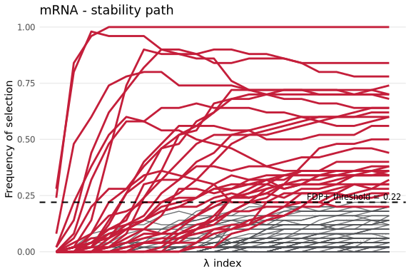

```r
print(plot_stabl_path(fit_mrna,  title = "mRNA - stability path"))
```

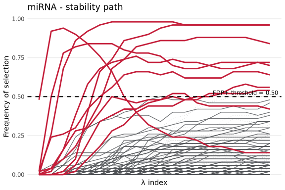

```r
print(plot_stabl_path(fit_mirna, title = "miRNA - stability path"))
```

## 3. Integrated multi-omic pipeline

```r
lambda_list <- list(
  mrna  = lambda_mrna,
  mirna = lambda_mirna
)
```

```r
multi_fit <- stabl_multiomic_train_validate(
  x_train_list    = list(mrna = X_train_mrna,  mirna = X_train_mirna),
  x_valid_list    = list(mrna = X_test_mrna,   mirna = X_test_mirna),
  y_train         = y_train,
  y_valid         = y_test,
  lambda_grid     = lambda_list,
  family          = "binomial",
  n_bootstraps    = 50L,
  artificial_type = "random_permutation",
  random_state    = 42L,
  early_fusion    = TRUE,
  late_fusion     = TRUE
)
multi_fit
```

```
#> <stabl_multiomic_fit>
#>   Omics:           2 (mrna, mirna)
#>   Per-omic selected features:
#>     mrna: 32
#>     mirna: 10
#>   Validation data:  yes
#>   Early fusion:     yes (35 features selected)
#>   Late fusion:      yes (score = 1)
```

## 4. Results exploration

### Per-omic biomarkers from the integrated fit

```r
cat("mRNA (integrated):\n")
```

```
#> mRNA (integrated):
```

```r
print(get_support(multi_fit$fits$mrna))
```

```
#>      RTN2     NDRG2   CCDC113    FAM63A     ACADS      GMDS     HLA-H    SEMA4A
#>     FALSE      TRUE     FALSE     FALSE     FALSE     FALSE     FALSE     FALSE
#>      ETS2     LIMD2      NME3      ZEB1     CDCP1     GIYD2     RTKN2    MANSC1
#>     FALSE     FALSE     FALSE     FALSE     FALSE     FALSE     FALSE     FALSE
#>     TAGLN     IFIT3     ARL4C     HTRA1    KIF13B    CPPED1     SKAP2      ASPM
#>     FALSE     FALSE     FALSE     FALSE     FALSE     FALSE     FALSE     FALSE
#>     KDM4B    TBXAS1      MT1X    MED13L    SNORA8      RGS1      CBX6      WWC2
#>     FALSE     FALSE     FALSE     FALSE      TRUE     FALSE     FALSE     FALSE
#> TNFRSF12A    ZNF552    MAPRE2    SEMA5A    STAT5A      FLI1   COL15A1   C7orf55
#>     FALSE      TRUE     FALSE     FALSE     FALSE     FALSE     FALSE     FALSE
#>     ASF1B      FUT8     LASS4      SQLE      GPC4    AKAP12       AGL   ADAMTS4
#>     FALSE      TRUE     FALSE     FALSE     FALSE     FALSE     FALSE     FALSE
#>     EPHB3    MAP3K1      PRNP     PROM2   SLCO3A1     SNHG1   PRKCDBP      MXI1
#>      TRUE     FALSE     FALSE     FALSE     FALSE     FALSE     FALSE     FALSE
#>     CSF1R     TANC2   SLC19A2      RHOU   C4orf34     LRIG1     DOCK8       BOC
#>     FALSE      TRUE     FALSE     FALSE      TRUE      TRUE     FALSE     FALSE
#>  C11orf52   S100A16     NRARP     TTC23    TBC1D4    DEPDC6     ILDR1      SDC1
#>     FALSE     FALSE     FALSE     FALSE      TRUE     FALSE     FALSE     FALSE
#>      STC2     DTWD2      TCF4     ITPR2      DPYD      NME1     EGLN3     CD302
#>     FALSE      TRUE     FALSE     FALSE     FALSE     FALSE     FALSE     FALSE
#>       AHR   LAPTM4B      OCLN HIST1H2BK    HDAC11   C18orf1  C6orf192     AMPD3
#>     FALSE     FALSE     FALSE     FALSE     FALSE     FALSE     FALSE     FALSE
#>    COL6A1   RAB3IL1   APBB1IP     PSIP1   EIF2AK2     CSRP2  EIF4EBP3       LYN
#>     FALSE     FALSE     FALSE      TRUE     FALSE     FALSE     FALSE      TRUE
#>     WDR76    SAMD9L      ASPH      RBL1   SLC43A3       HN1    TTC39A      MTL5
#>     FALSE     FALSE     FALSE     FALSE      TRUE     FALSE      TRUE     FALSE
#>       NES      APOD      RIN3     ALCAM   C1orf38     PLCD3     BSPRY      NTN4
#>      TRUE     FALSE      TRUE      TRUE     FALSE     FALSE     FALSE     FALSE
#>     IL1R1      EMP3   ZKSCAN1     FMNL2    OGFRL1      IRF5     IGSF3       DBP
#>     FALSE     FALSE     FALSE     FALSE      TRUE     FALSE     FALSE     FALSE
#>      CNN2    CAMK2D    SIGIRR     AKAP9      ICA1      FGD5      DSG2      E2F1
#>     FALSE     FALSE     FALSE     FALSE     FALSE     FALSE     FALSE     FALSE
#>     QSOX1      TOB1     CSF3R   SHROOM3    CCDC80     FRMD6    CXCL12     CCNA2
#>     FALSE     FALSE     FALSE      TRUE     FALSE     FALSE     FALSE     FALSE
#>     TIGD5   ALDH6A1     POSTN      FZD4    NCAPG2      SDC4     SNED1   PLEKHA4
#>      TRUE     FALSE     FALSE     FALSE      TRUE     FALSE     FALSE     FALSE
#>    KCNAB2   SH3KBP1     IGSF9      DNLZ     S1PR3     PTPRE  FLJ23867    PLSCR1
#>     FALSE     FALSE     FALSE     FALSE     FALSE     FALSE      TRUE     FALSE
#>      LMO4    IFITM2    LRRC25       TST      NCF4     NCOA7      IL4R   CCDC64B
#>     FALSE     FALSE     FALSE     FALSE     FALSE     FALSE     FALSE     FALSE
#>     SGPP1     RUNX3    SLC5A6     IFIH1     PREX1     PLAUR     CDK18   SLC43A2
#>     FALSE     FALSE      TRUE     FALSE      TRUE     FALSE      TRUE     FALSE
#>        GK     ICAM2     YPEL2      CBR1     MEX3A     ZNRF3     PTPRM  C1orf162
#>     FALSE     FALSE      TRUE      TRUE      TRUE     FALSE     FALSE     FALSE
#>      GAS6      C1QB     PVRL4      CTSK     MRVI1      LEF1     PLCD4    ZNF37B
#>     FALSE     FALSE     FALSE     FALSE     FALSE     FALSE     FALSE     FALSE
#>     MEGF9     GINS2    FAM13A     CPT1A     SNX10    TRIM45      ELP2     ALOX5
#>      TRUE     FALSE     FALSE      TRUE     FALSE     FALSE     FALSE     FALSE
#>      AMN1    CERCAM    SEMA3C      KRT8  TP53INP2      JAM3    ZNF680      PBX1
#>     FALSE     FALSE      TRUE      TRUE     FALSE     FALSE     FALSE     FALSE
```

```r
cat("\nmiRNA (integrated):\n")
```

```
#>
#> miRNA (integrated):
```

```r
print(get_support(multi_fit$fits$mirna))
```

```
#>   hsa-let-7a-1   hsa-let-7a-2   hsa-let-7a-3     hsa-let-7b     hsa-let-7c
#>          FALSE          FALSE          FALSE          FALSE          FALSE
#>     hsa-let-7d     hsa-let-7e   hsa-let-7f-1   hsa-let-7f-2     hsa-let-7g
#>          FALSE          FALSE          FALSE          FALSE          FALSE
#>     hsa-let-7i    hsa-mir-100  hsa-mir-101-1  hsa-mir-101-2  hsa-mir-103-1
#>          FALSE          FALSE          FALSE          FALSE          FALSE
#>  hsa-mir-103-2   hsa-mir-106a   hsa-mir-106b    hsa-mir-107    hsa-mir-10a
#>          FALSE           TRUE           TRUE          FALSE          FALSE
#>    hsa-mir-10b   hsa-mir-125a hsa-mir-125b-1    hsa-mir-126    hsa-mir-127
#>          FALSE          FALSE          FALSE          FALSE          FALSE
#>  hsa-mir-128-1  hsa-mir-128-2   hsa-mir-1287   hsa-mir-1301   hsa-mir-1307
#>          FALSE          FALSE          FALSE          FALSE          FALSE
#>   hsa-mir-130a   hsa-mir-130b    hsa-mir-132    hsa-mir-134    hsa-mir-139
#>          FALSE          FALSE          FALSE          FALSE          FALSE
#>    hsa-mir-140    hsa-mir-141    hsa-mir-142    hsa-mir-143    hsa-mir-144
#>          FALSE          FALSE          FALSE          FALSE          FALSE
#>    hsa-mir-145   hsa-mir-146a   hsa-mir-146b   hsa-mir-148a   hsa-mir-148b
#>          FALSE          FALSE          FALSE          FALSE          FALSE
#>    hsa-mir-149    hsa-mir-150    hsa-mir-151    hsa-mir-152    hsa-mir-155
#>           TRUE          FALSE          FALSE          FALSE          FALSE
#>    hsa-mir-15a    hsa-mir-15b   hsa-mir-16-1   hsa-mir-16-2     hsa-mir-17
#>          FALSE          FALSE          FALSE          FALSE           TRUE
#> hsa-mir-181a-1 hsa-mir-181a-2 hsa-mir-181b-1   hsa-mir-181c   hsa-mir-181d
#>          FALSE          FALSE          FALSE          FALSE          FALSE
#>    hsa-mir-182    hsa-mir-183    hsa-mir-185    hsa-mir-186    hsa-mir-191
#>          FALSE          FALSE          FALSE          FALSE          FALSE
#>    hsa-mir-192   hsa-mir-193a   hsa-mir-193b  hsa-mir-194-1  hsa-mir-194-2
#>          FALSE          FALSE          FALSE          FALSE          FALSE
#>    hsa-mir-195 hsa-mir-196a-1   hsa-mir-196b    hsa-mir-197 hsa-mir-199a-1
#>          FALSE          FALSE          FALSE          FALSE          FALSE
#> hsa-mir-199a-2   hsa-mir-199b  hsa-mir-19b-2   hsa-mir-200a   hsa-mir-200b
#>          FALSE          FALSE          FALSE          FALSE          FALSE
#>   hsa-mir-200c    hsa-mir-203    hsa-mir-205    hsa-mir-20a     hsa-mir-21
#>          FALSE          FALSE          FALSE           TRUE          FALSE
#>    hsa-mir-210    hsa-mir-214  hsa-mir-218-2     hsa-mir-22    hsa-mir-221
#>          FALSE          FALSE          FALSE          FALSE          FALSE
#>    hsa-mir-222    hsa-mir-223   hsa-mir-2355    hsa-mir-23a    hsa-mir-23b
#>          FALSE          FALSE          FALSE          FALSE          FALSE
#>   hsa-mir-24-1   hsa-mir-24-2     hsa-mir-25  hsa-mir-26a-2    hsa-mir-26b
#>          FALSE          FALSE          FALSE          FALSE          FALSE
```

[output cut: 19 more lines]

```
#>          FALSE          FALSE          FALSE           TRUE          FALSE
#>    hsa-mir-486    hsa-mir-497   hsa-mir-500a    hsa-mir-501    hsa-mir-505
#>          FALSE          FALSE          FALSE          FALSE           TRUE
#>    hsa-mir-532    hsa-mir-539    hsa-mir-542    hsa-mir-574    hsa-mir-576
#>          FALSE          FALSE          FALSE          FALSE          FALSE
#>    hsa-mir-582    hsa-mir-584    hsa-mir-589    hsa-mir-590    hsa-mir-625
#>          FALSE           TRUE          FALSE          FALSE          FALSE
#>    hsa-mir-628    hsa-mir-629    hsa-mir-660    hsa-mir-664    hsa-mir-7-1
#>          FALSE          FALSE          FALSE          FALSE          FALSE
#>    hsa-mir-708    hsa-mir-744    hsa-mir-769    hsa-mir-874    hsa-mir-9-1
#>          FALSE          FALSE          FALSE          FALSE          FALSE
#>    hsa-mir-9-2  hsa-mir-92a-1  hsa-mir-92a-2    hsa-mir-92b     hsa-mir-93
#>          FALSE          FALSE          FALSE          FALSE          FALSE
#>     hsa-mir-96     hsa-mir-98    hsa-mir-99a    hsa-mir-99b
#>          FALSE          FALSE          FALSE          FALSE
```

### Early fusion

```r
cat("Early fusion selected features:\n")
```

```
#> Early fusion selected features:
```

```r
print(get_support(multi_fit$early_fusion$fit))
```

```
#>           RTN2          NDRG2        CCDC113         FAM63A          ACADS
#>          FALSE           TRUE          FALSE          FALSE          FALSE
#>           GMDS          HLA-H         SEMA4A           ETS2          LIMD2
#>          FALSE          FALSE          FALSE          FALSE          FALSE
#>           NME3           ZEB1          CDCP1          GIYD2          RTKN2
#>          FALSE          FALSE          FALSE          FALSE          FALSE
#>         MANSC1          TAGLN          IFIT3          ARL4C          HTRA1
#>          FALSE          FALSE          FALSE          FALSE          FALSE
#>         KIF13B         CPPED1          SKAP2           ASPM          KDM4B
#>          FALSE          FALSE          FALSE          FALSE          FALSE
#>         TBXAS1           MT1X         MED13L         SNORA8           RGS1
#>          FALSE          FALSE          FALSE           TRUE          FALSE
#>           CBX6           WWC2      TNFRSF12A         ZNF552         MAPRE2
#>          FALSE          FALSE          FALSE           TRUE          FALSE
#>         SEMA5A         STAT5A           FLI1        COL15A1        C7orf55
#>          FALSE          FALSE          FALSE          FALSE          FALSE
#>          ASF1B           FUT8          LASS4           SQLE           GPC4
#>          FALSE           TRUE          FALSE          FALSE          FALSE
#>         AKAP12            AGL        ADAMTS4          EPHB3         MAP3K1
#>          FALSE          FALSE          FALSE           TRUE          FALSE
#>           PRNP          PROM2        SLCO3A1          SNHG1        PRKCDBP
#>          FALSE          FALSE          FALSE          FALSE          FALSE
#>           MXI1          CSF1R          TANC2        SLC19A2           RHOU
#>          FALSE          FALSE           TRUE          FALSE          FALSE
#>        C4orf34          LRIG1          DOCK8            BOC       C11orf52
#>           TRUE           TRUE          FALSE          FALSE          FALSE
#>        S100A16          NRARP          TTC23         TBC1D4         DEPDC6
#>          FALSE          FALSE          FALSE          FALSE          FALSE
#>          ILDR1           SDC1           STC2          DTWD2           TCF4
#>          FALSE          FALSE          FALSE           TRUE          FALSE
#>          ITPR2           DPYD           NME1          EGLN3          CD302
#>          FALSE          FALSE          FALSE          FALSE          FALSE
#>            AHR        LAPTM4B           OCLN      HIST1H2BK         HDAC11
#>          FALSE          FALSE          FALSE          FALSE          FALSE
#>        C18orf1       C6orf192          AMPD3         COL6A1        RAB3IL1
#>          FALSE          FALSE          FALSE          FALSE          FALSE
#>        APBB1IP          PSIP1        EIF2AK2          CSRP2       EIF4EBP3
#>          FALSE           TRUE          FALSE          FALSE          FALSE
#>            LYN          WDR76         SAMD9L           ASPH           RBL1
#>           TRUE          FALSE          FALSE          FALSE          FALSE
```

[output cut: 99 more lines]

```
#>          FALSE          FALSE          FALSE           TRUE          FALSE
#>    hsa-mir-486    hsa-mir-497   hsa-mir-500a    hsa-mir-501    hsa-mir-505
#>          FALSE          FALSE          FALSE          FALSE          FALSE
#>    hsa-mir-532    hsa-mir-539    hsa-mir-542    hsa-mir-574    hsa-mir-576
#>          FALSE          FALSE          FALSE          FALSE          FALSE
#>    hsa-mir-582    hsa-mir-584    hsa-mir-589    hsa-mir-590    hsa-mir-625
#>          FALSE          FALSE          FALSE          FALSE          FALSE
#>    hsa-mir-628    hsa-mir-629    hsa-mir-660    hsa-mir-664    hsa-mir-7-1
#>          FALSE          FALSE          FALSE          FALSE          FALSE
#>    hsa-mir-708    hsa-mir-744    hsa-mir-769    hsa-mir-874    hsa-mir-9-1
#>          FALSE          FALSE          FALSE          FALSE          FALSE
#>    hsa-mir-9-2  hsa-mir-92a-1  hsa-mir-92a-2    hsa-mir-92b     hsa-mir-93
#>           TRUE          FALSE          FALSE          FALSE          FALSE
#>     hsa-mir-96     hsa-mir-98    hsa-mir-99a    hsa-mir-99b
#>          FALSE          FALSE          FALSE          FALSE
```

### Late fusion weights

```r
cat("Late fusion omic weights:\n")
```

```
#> Late fusion omic weights:
```

```r
print(multi_fit$late_fusion$weights)
```

```
#>       Associated_weight
#> mrna           9.148060
#> mirna          9.370754
```

### Stability paths from integrated fit

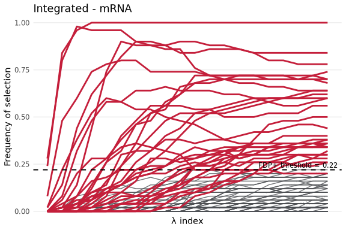

```r
print(plot_stabl_path(multi_fit$fits$mrna,  title = "Integrated - mRNA"))
```

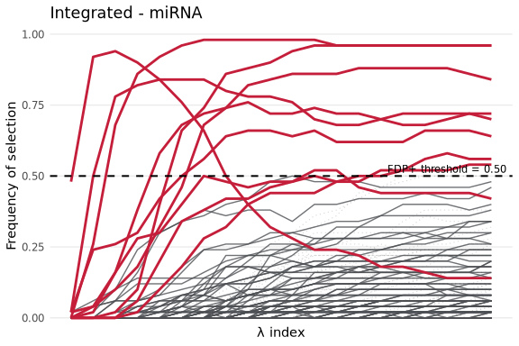

```r
print(plot_stabl_path(multi_fit$fits$mirna, title = "Integrated - miRNA"))
```

## 5. Validation performance

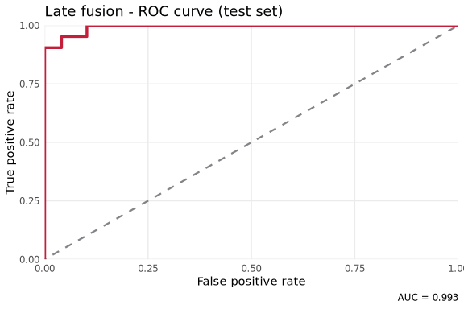

```r
lf_preds <- multi_fit$late_fusion$valid_predictions

plot_roc(y_true = y_test, y_preds = lf_preds,
         title = "Late fusion - ROC curve (test set)")
```

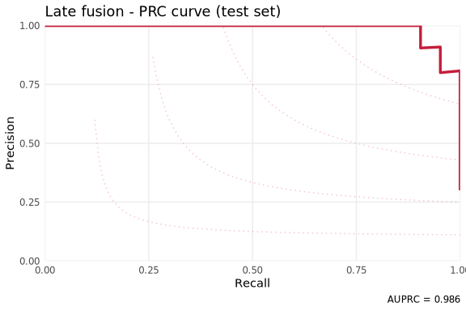

```r
plot_prc(y_true = y_test, y_preds = lf_preds,
         title = "Late fusion - PRC curve (test set)")
```

### Confusion matrix and balanced error rate (BER)

```r
pred_class <- as.integer(lf_preds >= 0.5)
conf_mat   <- table(Predicted = pred_class, Actual = y_test)
print(conf_mat)
```

```
#>          Actual
#> Predicted  0  1
#>         0 47  2
#>         1  2 19
```

```r
sensitivity <- conf_mat["1", "1"] / sum(conf_mat[, "1"])
specificity <- conf_mat["0", "0"] / sum(conf_mat[, "0"])
ber <- 1 - (sensitivity + specificity) / 2

cat(sprintf("\nSensitivity (Basal):     %.3f\n", sensitivity))
```

```
#>
#> Sensitivity (Basal):     0.905
```

```r
cat(sprintf("Specificity (non-Basal): %.3f\n", specificity))
```

```
#> Specificity (non-Basal): 0.959
```

```r
cat(sprintf("Balanced Error Rate:     %.3f\n", ber))
```

```
#> Balanced Error Rate:     0.068
```

### Feature distribution plots

[figure not shown]

```r
mrna_feats <- names(which(get_support(multi_fit$fits$mrna)))
if (length(mrna_feats) > 0) {
  boxplot_features(
    features = mrna_feats,
    x        = X_train_mrna,
    y        = y_train,
    title    = "Top mRNA features - training set",
    ncol     = min(3L, length(mrna_feats))
  )
}
```

## 6. Export results

```r
export_stabl_to_csv(multi_fit$fits$mrna,  path = "tcga_results/mrna")
export_stabl_to_csv(multi_fit$fits$mirna, path = "tcga_results/mirna")
```

`export_stabl_to_csv()` writes per-call:

- `<prefix>_stability_scores.csv` - all features with stability scores, sorted.
- `<prefix>_selected_features.csv` - features passing the threshold with FDP.

## 7. Comparison with mixOmics

| Aspect | mixOmics (sgccaDA) | stablr |
| --- | --- | --- |
| Method | Sparse CCA + LDA | Bootstrap-stability LASSO |
| Feature selection | L1 penalty tuned by CV | FDP-controlled stability threshold |
| Integration | Joint latent-space optimisation | Early or late fusion |
| Primary metric | BER on test set | FDP+ stability score |
| Output | Components + loadings | Feature names + stability scores |

Both approaches identify a compact, reliable set of mRNA and miRNA biomarkers for the Basal subtype. STABL’s advantage is explicit FDP control with no assumption of a shared latent space between omics.

## Next steps

- See `vignette("stablr-multiomic")` for a regression multi-omic example.
- See `vignette("stablr-python-parity")` for a Python vs. R result comparison.
- Increase `n_bootstraps` to 500-1000 for publication-quality results.
- Try `artificial_type = "knockoff"` for stronger FDP control.